# Regression Project

## Exploratory Analysis:

Remember that 0=Automatic and 1=Manual

```r
data(mtcars)
data=data.frame(mtcars)
table(data$am)
```

```
##
##  0  1
## 19 13
```

At first glance, it seems that manual has better mileage than automatic.

```r
mpg_manual=subset(data,data$am==1)
mpg_automatic=subset(data,data$am==0)
summary(mpg_manual$mpg)
```

```
##    Min. 1st Qu.  Median    Mean 3rd Qu.    Max.
##   15.00   21.00   22.80   24.39   30.40   33.90
```

```r
summary(mpg_automatic$mpg)
```

```
##    Min. 1st Qu.  Median    Mean 3rd Qu.    Max.
##   10.40   14.95   17.30   17.15   19.20   24.40
```

However, it seems that automatic cars are generally heavier,have more cylinders, and have more horsepower, and more displacement, which can all be factors in causing worse mileage. (Look at pairs function output and histogram in appendix).

```r
sapply(mpg_manual,mean)
```

```
##         mpg         cyl        disp          hp        drat          wt
##  24.3923077   5.0769231 143.5307692 126.8461538   4.0500000   2.4110000
##        qsec          vs          am        gear        carb
##  17.3600000   0.5384615   1.0000000   4.3846154   2.9230769
```

```r
sapply(mpg_automatic,mean)
```

```
##         mpg         cyl        disp          hp        drat          wt
##  17.1473684   6.9473684 290.3789474 160.2631579   3.2863158   3.7688947
##        qsec          vs          am        gear        carb
##  18.1831579   0.3684211   0.0000000   3.2105263   2.7368421
```

## Here’s some models

First, look just at mpg versus manual/automatic.This shows that ignoring all other variables, 95% confidence interval shows manual has better mileage.

```r
fits=lm(data$mpg~factor(data$am))
        fits_coeff=summary(fits)$coefficients
        fits_coeff[2,1]
```

```
## [1] 7.244939
```

```r
        qt(.975,32-4)*fits_coeff[2,2]*c(-1,1)+fits_coeff[2,1]
```

```
## [1]  3.630685 10.859193
```

We do a model comparing mpg and weight since weight is known to affect mpg a lot (look at pairs() diagram for confirmation of this) (Plots of fit0 are in Appendix)

```r
fit0=lm(data$mpg~data$wt)
```

Here, we add manual/automatic variable as an interaction with weight. We also calculate the confidence interval. The model shows that within 95% confidence interval, automatic has better mpg for high weight and worse for lighter weight (around a little less than 3000 pounds is where intersect is)

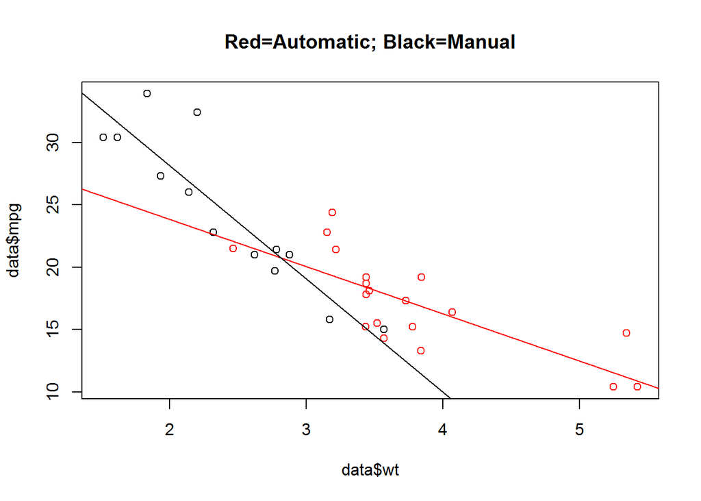

```r
fit=lm(data$mpg~data$wt+data$am*data$wt)
plot(data$wt,data$mpg,col=(data$am==0)*1+1)
abline(c(fit$coefficients[1],fit$coefficients[2]),col=2)
abline(c(fit$coefficients[1]+fit$coefficients[3],fit$coefficients[2]+fit$coefficients[4]),col=1)
title("Red=Automatic; Black=Manual")
```

```r
        ###Calculate confidence interval of fit
                fit_coeff=summary(fit)$coefficients
                qt(.975,32-4)*fit_coeff[4,2]*c(-1,1)+fit_coeff[4,1] ##
```

```
## [1] -8.257693 -2.339028
```

```r
fit2=lm(data$mpg~data$wt+data$am*data$wt+data$disp)
fit3=lm(data$mpg~data$wt+data$am*data$wt+data$disp+data$hp)
anova(fit0,fit,fit2,fit3)
```

```
## Analysis of Variance Table
##
## Model 1: data$mpg ~ data$wt
## Model 2: data$mpg ~ data$wt + data$am * data$wt
## Model 3: data$mpg ~ data$wt + data$am * data$wt + data$disp
## Model 4: data$mpg ~ data$wt + data$am * data$wt + data$disp + data$hp
##   Res.Df    RSS Df Sum of Sq      F   Pr(>F)
## 1     30 278.32
## 2     28 188.01  2    90.314 8.1409 0.001797 **
## 3     27 157.06  1    30.948 5.5793 0.025942 *
## 4     26 144.22  1    12.840 2.3148 0.140219
## ---
## Signif. codes:  0 '***' 0.001 '**' 0.01 '*' 0.05 '.' 0.1 ' ' 1
```

## APPENDIX

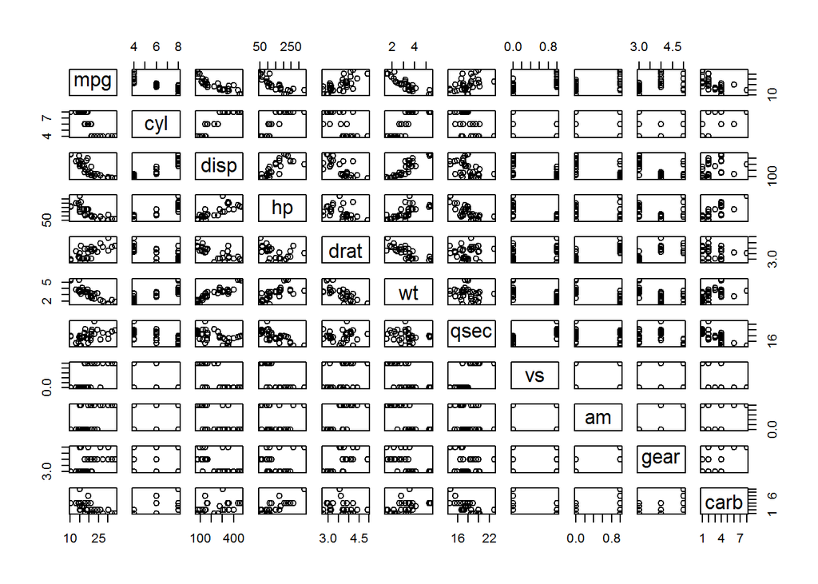

```r
###From graphs, it seems weight, horsepower, number of cylinders, displacement all seem to negatively affect mpg.  Knowing this, it's unclear how automatic and manual settings affect mpg
pairs(data)
```

Here’s a histogram to give us a better look at the mpg of automatic and manual cars. Manual cars seem to have more MPG.

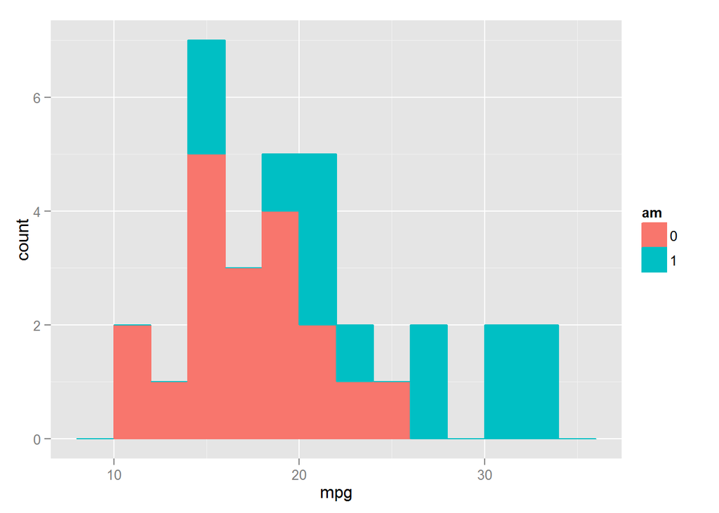

```r
library(ggplot2)
data$am=factor(data$am)
qplot(mpg,data=data,color=am,binwidth=2,fill=am)
```

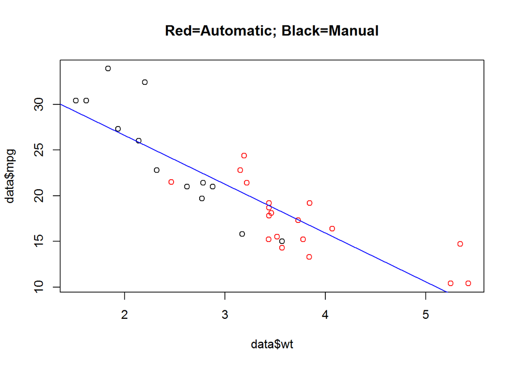

```r
###plot of model fit0
plot(data$wt,data$mpg,col=(data$am==0)*1+1)
abline(c(fit0$coefficients[1],fit0$coefficients[2]),col=4)
title("Red=Automatic; Black=Manual")
```

### Residuals and Diagnostics:

We calculate some residuals. The plot shows residuals are good for model fit, there’s no discernible pattern, and taking regression of resids shows no slope to residuals.

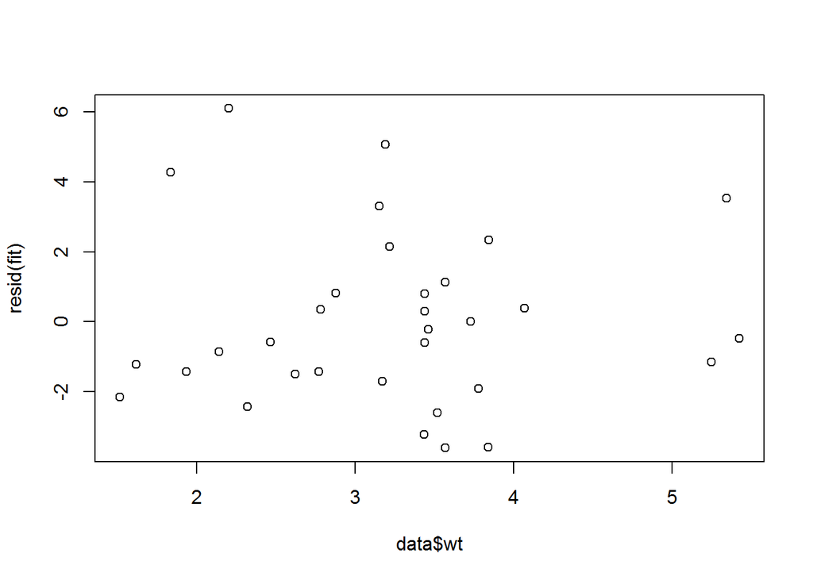

```r
plot(data$wt,resid(fit))
```

```r
lm(data$wt~resid(fit))##
```

```
##
## Call:
## lm(formula = data$wt ~ resid(fit))
##
## Coefficients:
## (Intercept)   resid(fit)
##   3.217e+00    8.097e-18
```

Fit shows a slight downward slope to resids, which indicates this model doesn’t fit the data well. This is shown below.

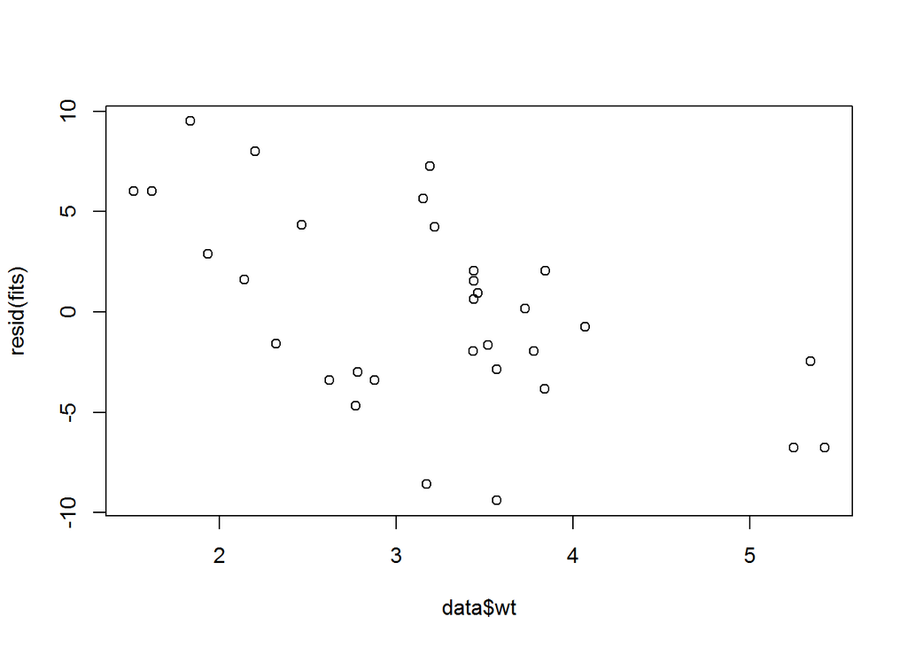

```r
plot(data$wt,resid(fits))
```

```r
lm(data$wt~resid(fits))
```

```
##
## Call:
## lm(formula = data$wt ~ resid(fits))
##
## Coefficients:
## (Intercept)  resid(fits)
##      3.2172      -0.1147
```

Doing a dfbetas, we not that the max in dfbetas for our interaction coefficient(weight&am) is relatively small ~.4, which is less than 10% of coefficient’s value.

```r
dfbetas=dfbetas(fit)
max(dfbetas[,4]) ##
```

```
## [1] 0.3913157
```

```r
t.test(mpg_manual,mpg_automatic)
```

```
##
##  Welch Two Sample t-test
##
## data:  mpg_manual and mpg_automatic
## t = -1.8772, df = 348.4, p-value = 0.06132
## alternative hypothesis: true difference in means is not equal to 0
## 95 percent confidence interval:
##  -32.3497623   0.7538182
## sample estimates:
## mean of x mean of y
##  30.22848  46.02645
```